# Loan Data from Prosper - (Exploratory Instructions)

## Introduction

This dataset [Loan Data from Prosper](https://learn.udacity.com/nanodegrees/nd002-palestine/parts/cd12532/lessons/e2bc9638-6516-4ddb-928e-09e05c20f7f5/concepts/28cb2079-4123-4fe3-b20d-018abb2fe2cb) provides a comprehensive collection of 113,937 loans, encompassing a wide range of variables that offer detailed insights into each loan. With 81 variables per loan, the dataset includes crucial information such as the loan amount, borrower rate (or interest rate), current loan status, and borrower income, among many other attributes. These variables collectively enable an in-depth analysis of loan characteristics, borrower demographics, and financial trends. To facilitate a better understanding of the dataset, please refer to the data dictionary below, which describes each variable in detail.

After this stage (Data exploration) we most be able to answer thouse questions:

1. What is the distribution of loan terms (in months) among the loans in the dataset?
2. How is the frequency of different employment statuses distributed in the dataset, and what are the counts for each category?
3. What is the frequency distribution of borrowers income ranges in the dataset, and how do the counts compare across predefined income categories?
4. How are loans distributed across different loan origination quarters in the dataset, and what are the counts for each quarter over time?
5. What is the strongest correlation with Monthly Loan Payment?*
6. How does the relationship between the original loan amount and monthly loan payment vary across different income ranges?
7. How does the Borrower APR vary across different loan terms and employment statuses?
8. How does the Monthly Loan Payment vary for different loan statuses and whether the borrower is a homeowner or not?

## Description

This dataset contains 113,937 loans with 81 variables on each loan, including detailed information about loan amounts, borrower rates, loan status, borrower income, and many other attributes. Below is a description of each column in the dataset:

- **ListingKey**: Unique key for each listing, same value as the 'key' used in the listing object in the API.
- **ListingNumber**: The number that uniquely identifies the listing to the public as displayed on the website.
- **ListingCreationDate**: The date the listing was created.
- **CreditGrade**: The Credit rating that was assigned at the time the listing went live. Applicable for listings pre-2009 period and will only be populated for those listings.
- **Term**: The length of the loan expressed in months.
- **LoanStatus**: The current status of the loan: Cancelled, Chargedoff, Completed, Current, Defaulted, FinalPaymentInProgress, PastDue. The PastDue status will be accompanied by a delinquency bucket.
- **ClosedDate**: Closed date is applicable for Cancelled, Completed, Chargedoff and Defaulted loan statuses.
- **BorrowerAPR**: The Borrower's Annual Percentage Rate (APR) for the loan.
- **BorrowerRate**: The Borrower's interest rate for this loan.
- **LenderYield**: The Lender yield on the loan. Lender yield is equal to the interest rate on the loan less the servicing fee.
- **EstimatedEffectiveYield**: Effective yield is equal to the borrower interest rate minus the servicing fee rate, minus estimated uncollected interest on charge-offs, plus estimated collected late fees. Applicable for loans originated after July 2009.
- **EstimatedLoss**: Estimated loss is the estimated principal loss on charge-offs. Applicable for loans originated after July 2009.
- **EstimatedReturn**: The estimated return assigned to the listing at the time it was created. Estimated return is the difference between the Estimated Effective Yield and the Estimated Loss Rate. Applicable for loans originated after July 2009.
- **ProsperRating (numeric)**: The Prosper Rating assigned at the time the listing was created: 0 - N/A, 1 - HR, 2 - E, 3 - D, 4 - C, 5 - B, 6 - A, 7 - AA. Applicable for loans originated after July 2009.
- **ProsperRating (Alpha)**: The Prosper Rating assigned at the time the listing was created between AA - HR. Applicable for loans originated after July 2009.
- **ProsperScore**: A custom risk score built using historical Prosper data. The score ranges from 1-10, with 10 being the best, or lowest risk score. Applicable for loans originated after July 2009.
- **ListingCategory**: The category of the listing that the borrower selected when posting their listing: 0 - Not Available, 1 - Debt Consolidation, 2 - Home Improvement, 3 - Business, 4 - Personal Loan, 5 - Student Use, 6 - Auto, 7 - Other, 8 - Baby & Adoption, 9 - Boat, 10 - Cosmetic Procedure, 11 - Engagement Ring, 12 - Green Loans, 13 - Household Expenses, 14 - Large Purchases, 15 - Medical/Dental, 16 - Motorcycle, 17 - RV, 18 - Taxes, 19 - Vacation, 20 - Wedding Loans.
- **BorrowerState**: The two-letter abbreviation of the state of the address of the borrower at the time the Listing was created.
- **Occupation**: The Occupation selected by the Borrower at the time they created the listing.
- **EmploymentStatus**: The employment status of the borrower at the time they posted the listing.
- **EmploymentStatusDuration**: The length in months of the employment status at the time the listing was created.
- **IsBorrowerHomeowner**: A Borrower will be classified as a homeowner if they have a mortgage on their credit profile or provide documentation confirming they are a homeowner.
- **CurrentlyInGroup**: Specifies whether or not the Borrower was in a group at the time the listing was created.
- **GroupKey**: The Key of the group in which the Borrower is a member of. Value will be null if the borrower does not have a group affiliation.
- **DateCreditPulled**: The date the credit profile was pulled.
- **CreditScoreRangeLower**: The lower value representing the range of the borrower's credit score as provided by a consumer credit rating agency.
- **CreditScoreRangeUpper**: The upper value representing the range of the borrower's credit score as provided by a consumer credit rating agency.
- **FirstRecordedCreditLine**: The date the first credit line was opened.
- **CurrentCreditLines**: Number of current credit lines at the time the credit profile was pulled.
- **OpenCreditLines**: Number of open credit lines at the time the credit profile was pulled.
- **TotalCreditLinespast7years**: Number of credit lines in the past seven years at the time the credit profile was pulled.
- **OpenRevolvingAccounts**: Number of open revolving accounts at the time the credit profile was pulled.
- **OpenRevolvingMonthlyPayment**: Monthly payment on revolving accounts at the time the credit profile was pulled.
- **InquiriesLast6Months**: Number of inquiries in the past six months at the time the credit profile was pulled.
- **TotalInquiries**: Total number of inquiries at the time the credit profile was pulled.
- **CurrentDelinquencies**: Number of accounts delinquent at the time the credit profile was pulled.
- **AmountDelinquent**: Dollars delinquent at the time the credit profile was pulled.
- **DelinquenciesLast7Years**: Number of delinquencies in the past 7 years at the time the credit profile was pulled.
- **PublicRecordsLast10Years**: Number of public records in the past 10 years at the time the credit profile was pulled.
- **PublicRecordsLast12Months**: Number of public records in the past 12 months at the time the credit profile was pulled.
- **RevolvingCreditBalance**: Dollars of revolving credit at the time the credit profile was pulled.
- **BankcardUtilization**: The percentage of available revolving credit that is utilized at the time the credit profile was pulled.
- **AvailableBankcardCredit**: The total available credit via bank card at the time the credit profile was pulled.
- **TotalTrades**: Number of trade lines ever opened at the time the credit profile was pulled.
- **TradesNeverDelinquent**: Number of trades that have never been delinquent at the time the credit profile was pulled.
- **TradesOpenedLast6Months**: Number of trades opened in the last 6 months at the time the credit profile was pulled.
- **DebtToIncomeRatio**: The debt to income ratio of the borrower at the time the credit profile was pulled. This value is Null if the debt to income ratio is not available. This value is capped at 10.01 (any debt to income ratio larger than 1000% will be returned as 1001%).
- **IncomeRange**: The income range of the borrower at the time the listing was created.
- **IncomeVerifiable**: The borrower indicated they have the required documentation to support their income.
- **StatedMonthlyIncome**: The monthly income the borrower stated at the time the listing was created.
- **LoanKey**: Unique key for each loan. This is the same key that is used in the API.
- **TotalProsperLoans**: Number of Prosper loans the borrower at the time they created this listing. This value will be null if the borrower had no prior loans.
- **TotalProsperPaymentsBilled**: Number of on-time payments the borrower made on Prosper loans at the time they created this listing. This value will be null if the borrower had no prior loans.
- **OnTimeProsperPayments**: Number of on-time payments the borrower had made on Prosper loans at the time they created this listing. This value will be null if the borrower has no prior loans.
- **ProsperPaymentsLessThanOneMonthLate**: Number of payments the borrower made on Prosper loans that were less than one month late at the time they created this listing. This value will be null if the borrower had no prior loans.
- **ProsperPaymentsOneMonthPlusLate**: Number of payments the borrower made on Prosper loans that were greater than one month late at the time they created this listing. This value will be null if the borrower had no prior loans.
- **ProsperPrincipalBorrowed**: Total principal borrowed on Prosper loans at the time the listing was created. This value will be null if the borrower had no prior loans.
- **ProsperPrincipalOutstanding**: Principal outstanding on Prosper loans at the time the listing was created. This value will be null if the borrower had no prior loans.
- **ScorexChangeAtTimeOfListing**: Borrower's credit score change at the time the credit profile was pulled. This will be the change relative to the borrower's last Prosper loan. This value will be null if the borrower had no prior loans.
- **LoanCurrentDaysDelinquent**: The number of days delinquent.
- **LoanFirstDefaultedCycleNumber**: The cycle the loan was charged off. If the loan has not charged off the value will be null.
- **LoanMonthsSinceOrigination**: Number of months since the loan originated.
- **LoanNumber**: Unique numeric value associated with the loan.
- **LoanOriginalAmount**: The origination amount of the loan.
- **LoanOriginationDate**: The date the loan was originated.
- **LoanOriginationQuarter**: The quarter in which the loan was originated.
- **MemberKey**: The unique key that is associated with the borrower. This is the same identifier that is used in the API member object.
- **MonthlyLoanPayment**: The scheduled monthly loan payment.
- **LP_CustomerPayments**: Pre charge-off cumulative gross payments made by the borrower on the loan. If the loan has charged off, this value will exclude any recoveries.
- **LP_CustomerPrincipalPayments**: Pre charge-off cumulative principal payments made by the borrower on the loan. If the loan has charged off, this value will exclude any recoveries.
- **LP_InterestandFees**: Pre charge-off cumulative interest and fees paid by the borrower. If the loan has charged off, this value will exclude any recoveries.
- **LP_ServiceFees**: Cumulative service fees paid by the investors who have invested in the loan.
- **LP_CollectionFees**: Cumulative collection fees paid by the investors who have invested in the loan.
- **LP_GrossPrincipalLoss**: The gross charged off amount of the loan.
- **LP_NetPrincipalLoss**: The principal that remains uncollected after any recoveries.
- **LP_NonPrincipalRecoverypayments**: The interest and fee component of any recovery payments. The current payment policy applies payments in the following order: Fees, interest, principal.
- **PercentFunded**: Percent the listing was funded.
- **Recommendations**: Number of recommendations the borrower had at the time the listing was created.
- **InvestmentFromFriendsCount**: Number of friends that made an investment in the loan.
- **InvestmentFromFriendsAmount**: Dollar amount of investments that were made by friends.
- **Investors**: The number of investors that funded the loan.

## Data Wrangling phase

Importing all the librares we need in our process

```python
import pandas as pd  # Data manipulation
import numpy as np  # Numerical operations
import seaborn as sns  # Data visualization
import requests  # HTTP requests
import matplotlib.pyplot as plt  # Plotting
import warnings  # Manage warnings
```

For ignoring the unnsereary warninngs

```python
warnings.filterwarnings("ignore")
```

### 1. Data Gathering

Reading the csv file (Loan Data from Prosper)

```python
loan = pd.read_csv('../datasets/prosperLoanData.csv') # Reading the csv file
loan.sample(3)
```

|  | ListingKey | ListingNumber | ListingCreationDate | CreditGrade | Term | LoanStatus | ClosedDate | BorrowerAPR | BorrowerRate | LenderYield | ... | LP_ServiceFees | LP_CollectionFees | LP_GrossPrincipalLoss | LP_NetPrincipalLoss | LP_NonPrincipalRecoverypayments | PercentFunded | Recommendations | InvestmentFromFriendsCount | InvestmentFromFriendsAmount | Investors |
| --- | --- | --- | --- | --- | --- | --- | --- | --- | --- | --- | --- | --- | --- | --- | --- | --- | --- | --- | --- | --- | --- |
| 51124 | A63E3572440720090C6F90B | 727592 | 2013-03-13 15:12:12.400000000 | NaN | 36 | Current | NaN | 0.15833 | 0.1299 | 0.1199 | ... | -26.06 | 0.0 | 0.0 | 0.0 | 0.0 | 1.0 | 0 | 0 | 0.0 | 46 |
| 66096 | D75635919909889591C4553 | 963237 | 2013-10-07 04:41:49.610000000 | NaN | 36 | Current | NaN | 0.30899 | 0.2699 | 0.2599 | ... | -13.11 | 0.0 | 0.0 | 0.0 | 0.0 | 1.0 | 0 | 0 | 0.0 | 1 |
| 48258 | F20D3462972296508B5379A | 424094 | 2009-09-12 08:41:31.777000000 | NaN | 36 | Completed | 2011-04-19 00:00:00 | 0.15144 | 0.1300 | 0.1200 | ... | -41.39 | 0.0 | 0.0 | 0.0 | 0.0 | 1.0 | 0 | 0 | 0.0 | 228 |

3 rows × 81 columns

The dataset exist we dont need to store

```python
loan.shape
```

```
(113937, 81)
```

### 2. Assess the data

#### Completeness

```python
loan.isna().sum()
```

```
ListingKey                         0
ListingNumber                      0
ListingCreationDate                0
CreditGrade                    84984
Term                               0
                               ...
PercentFunded                      0
Recommendations                    0
InvestmentFromFriendsCount         0
InvestmentFromFriendsAmount        0
Investors                          0
Length: 81, dtype: int64
```

Not complete data there is a lot of missing values

#### Validity

```python
loan.dtypes
```

```
ListingKey                      object
ListingNumber                    int64
ListingCreationDate             object
CreditGrade                     object
Term                             int64
                                ...
PercentFunded                  float64
Recommendations                  int64
InvestmentFromFriendsCount       int64
InvestmentFromFriendsAmount    float64
Investors                        int64
Length: 81, dtype: object
```

There is some issues with Validity the data types most be correct like : ListingCreationDate, ClosedDate, LoanOriginationDate

#### Accuracy

```python
loan.describe()
```

|  | ListingNumber | Term | BorrowerAPR | BorrowerRate | LenderYield | EstimatedEffectiveYield | EstimatedLoss | EstimatedReturn | ProsperRating (numeric) | ProsperScore | ... | LP_ServiceFees | LP_CollectionFees | LP_GrossPrincipalLoss | LP_NetPrincipalLoss | LP_NonPrincipalRecoverypayments | PercentFunded | Recommendations | InvestmentFromFriendsCount | InvestmentFromFriendsAmount | Investors |
| --- | --- | --- | --- | --- | --- | --- | --- | --- | --- | --- | --- | --- | --- | --- | --- | --- | --- | --- | --- | --- | --- |
| count | 1.139370e+05 | 113937.000000 | 113912.000000 | 113937.000000 | 113937.000000 | 84853.000000 | 84853.000000 | 84853.000000 | 84853.000000 | 84853.000000 | ... | 113937.000000 | 113937.000000 | 113937.000000 | 113937.000000 | 113937.000000 | 113937.000000 | 113937.000000 | 113937.000000 | 113937.000000 | 113937.000000 |
| mean | 6.278857e+05 | 40.830248 | 0.218828 | 0.192764 | 0.182701 | 0.168661 | 0.080306 | 0.096068 | 4.072243 | 5.950067 | ... | -54.725641 | -14.242698 | 700.446342 | 681.420499 | 25.142686 | 0.998584 | 0.048027 | 0.023460 | 16.550751 | 80.475228 |
| std | 3.280762e+05 | 10.436212 | 0.080364 | 0.074818 | 0.074516 | 0.068467 | 0.046764 | 0.030403 | 1.673227 | 2.376501 | ... | 60.675425 | 109.232758 | 2388.513831 | 2357.167068 | 275.657937 | 0.017919 | 0.332353 | 0.232412 | 294.545422 | 103.239020 |
| min | 4.000000e+00 | 12.000000 | 0.006530 | 0.000000 | -0.010000 | -0.182700 | 0.004900 | -0.182700 | 1.000000 | 1.000000 | ... | -664.870000 | -9274.750000 | -94.200000 | -954.550000 | 0.000000 | 0.700000 | 0.000000 | 0.000000 | 0.000000 | 1.000000 |
| 25% | 4.009190e+05 | 36.000000 | 0.156290 | 0.134000 | 0.124200 | 0.115670 | 0.042400 | 0.074080 | 3.000000 | 4.000000 | ... | -73.180000 | 0.000000 | 0.000000 | 0.000000 | 0.000000 | 1.000000 | 0.000000 | 0.000000 | 0.000000 | 2.000000 |
| 50% | 6.005540e+05 | 36.000000 | 0.209760 | 0.184000 | 0.173000 | 0.161500 | 0.072400 | 0.091700 | 4.000000 | 6.000000 | ... | -34.440000 | 0.000000 | 0.000000 | 0.000000 | 0.000000 | 1.000000 | 0.000000 | 0.000000 | 0.000000 | 44.000000 |
| 75% | 8.926340e+05 | 36.000000 | 0.283810 | 0.250000 | 0.240000 | 0.224300 | 0.112000 | 0.116600 | 5.000000 | 8.000000 | ... | -13.920000 | 0.000000 | 0.000000 | 0.000000 | 0.000000 | 1.000000 | 0.000000 | 0.000000 | 0.000000 | 115.000000 |
| max | 1.255725e+06 | 60.000000 | 0.512290 | 0.497500 | 0.492500 | 0.319900 | 0.366000 | 0.283700 | 7.000000 | 11.000000 | ... | 32.060000 | 0.000000 | 25000.000000 | 25000.000000 | 21117.900000 | 1.012500 | 39.000000 | 33.000000 | 25000.000000 | 1189.000000 |

8 rows × 61 columns

Wee can see the there is a lot of huge differance between some of fetures and it mean

#### Consistency

```python
loan['CreditGrade'].value_counts()
```

```
CreditGrade
C     5649
D     5153
B     4389
AA    3509
HR    3508
A     3315
E     3289
NC     141
Name: count, dtype: int64
```

```python
loan['EmploymentStatus'].value_counts()
```

```
EmploymentStatus
Employed         67322
Full-time        26355
Self-employed     6134
Not available     5347
Other             3806
Part-time         1088
Not employed       835
Retired            795
Name: count, dtype: int64
```

It seems consistent

#### Uniqueness

```python
loan.duplicated().sum()
```

```
0
```

It unique

#### But there is a lot of messy issues like we dont dont need all the columns so we most choose the columns that we want to build the Analysis on it

### 3. Clean the data

First choose the columns that we want amonge all the columns

```python
selected_columns = [
    'ListingCreationDate', 'Term', 'LoanStatus', 'BorrowerAPR',
    'BorrowerRate', 'LenderYield', 'ListingCategory (numeric)',
    'EmploymentStatus', 'EmploymentStatusDuration', 'IsBorrowerHomeowner',
    'IncomeRange', 'IncomeVerifiable', 'StatedMonthlyIncome',
    'LoanOriginalAmount', 'LoanOriginationDate', 'LoanOriginationQuarter',
    'MonthlyLoanPayment'
]
loan = loan[selected_columns]
```

Removing the missing values we have a lot of data so thats find

```python
loan = loan.dropna()
loan.shape
```

```
(106312, 17)
```

Handeling the data types

```python
loan['LoanOriginationDate'] = pd.to_datetime(loan['LoanOriginationDate'])
```

```python
def extract_date(datetime_str):
    return datetime_str.split(' ')[0]

loan['ListingCreationDate'] = loan['ListingCreationDate'].apply(extract_date)
loan['ListingCreationDate'] = pd.to_datetime(loan['ListingCreationDate'])
loan[['LoanOriginationDate','ListingCreationDate']].sample(3)
```

|  | LoanOriginationDate | ListingCreationDate |
| --- | --- | --- |
| 2232 | 2013-06-20 | 2013-05-31 |
| 102174 | 2014-01-09 | 2014-01-03 |
| 79492 | 2013-11-18 | 2013-09-22 |

Check if there still missing values

```python
loan.isna().sum()
```

```
ListingCreationDate          0
Term                         0
LoanStatus                   0
BorrowerAPR                  0
BorrowerRate                 0
LenderYield                  0
ListingCategory (numeric)    0
EmploymentStatus             0
EmploymentStatusDuration     0
IsBorrowerHomeowner          0
IncomeRange                  0
IncomeVerifiable             0
StatedMonthlyIncome          0
LoanOriginalAmount           0
LoanOriginationDate          0
LoanOriginationQuarter       0
MonthlyLoanPayment           0
dtype: int64
```

Check if there is dublicated vlaues

```python
loan.duplicated().sum()
```

```
872
```

Drop it

```python
loan = loan.drop_duplicates()
```

See the data type

```python
loan.info()
```

```
<class 'pandas.core.frame.DataFrame'>
Index: 105440 entries, 0 to 113936
Data columns (total 17 columns):
 #   Column                     Non-Null Count   Dtype
---  ------                     --------------   -----
 0   ListingCreationDate        105440 non-null  datetime64[ns]
 1   Term                       105440 non-null  int64
 2   LoanStatus                 105440 non-null  object
 3   BorrowerAPR                105440 non-null  float64
 4   BorrowerRate               105440 non-null  float64
 5   LenderYield                105440 non-null  float64
 6   ListingCategory (numeric)  105440 non-null  int64
 7   EmploymentStatus           105440 non-null  object
 8   EmploymentStatusDuration   105440 non-null  float64
 9   IsBorrowerHomeowner        105440 non-null  bool
 10  IncomeRange                105440 non-null  object
 11  IncomeVerifiable           105440 non-null  bool
 12  StatedMonthlyIncome        105440 non-null  float64
 13  LoanOriginalAmount         105440 non-null  int64
 14  LoanOriginationDate        105440 non-null  datetime64[ns]
 15  LoanOriginationQuarter     105440 non-null  object
 16  MonthlyLoanPayment         105440 non-null  float64
dtypes: bool(2), datetime64[ns](2), float64(6), int64(3), object(4)
memory usage: 13.1+ MB
```

Look at the shape after cleaning

```python
loan.shape
```

```
(105440, 17)
```

### 4. Store data

Save the dataset after cleaning phase

```python
loan.to_csv('../datasets/loanCleand.csv', index=False) # Save the cleand dataset
```

## Explore Data Analysis phase

### Univariate exploration

Create a function for build a histograms for the numarical values

```python
def plot_histograms(data, column, x_label, y_label):
    plt.figure(figsize=(10, 6))
    plt.hist(data[column].dropna(), bins=30, edgecolor='k')
    plt.title(f'Distribution of {x_label}')
    plt.xlabel(x_label)
    plt.ylabel(y_label)
    plt.show()
```

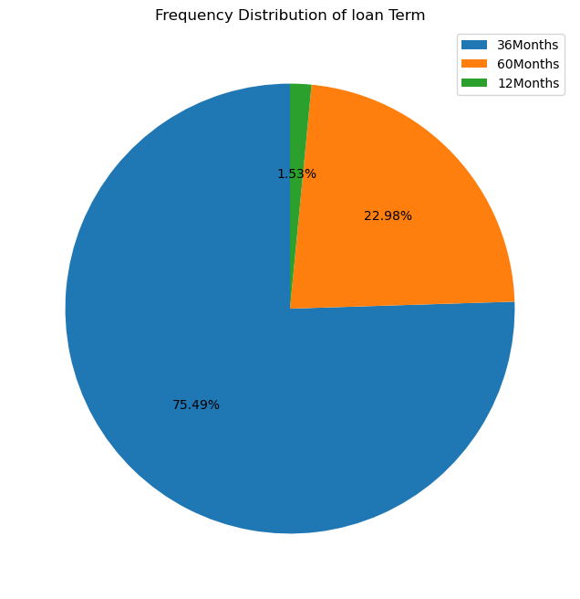

```python
plt.figure(figsize=[8,8])
labels = '36Months','60Months','12Months'
plt.pie(loan['Term'].value_counts(), autopct='%1.2f%%',startangle=90)
plt.title('Frequency Distribution of loan Term')
plt.legend(labels);
```

**We can see the 75% of the data is 36 and 22% is 60 and the rest is 12**

Build a histogram for BorrowerAPR column

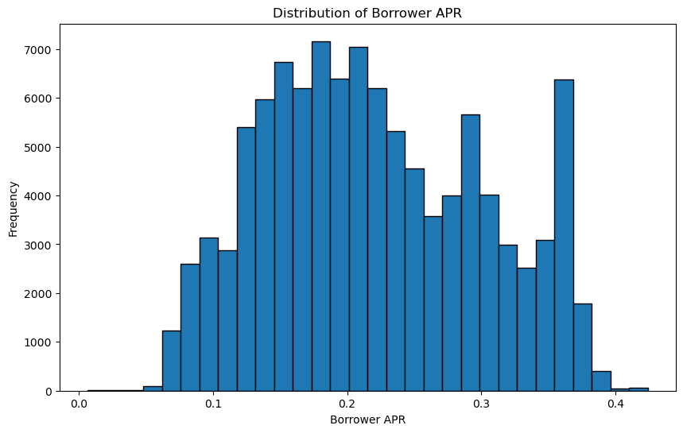

```python
plot_histograms(loan, 'BorrowerAPR', 'Borrower APR', 'Frequency')
```

**As wee see from the histogram the data have small squet to the rigth about the mean 0.2**

Build a histogram for BorrowerRate column

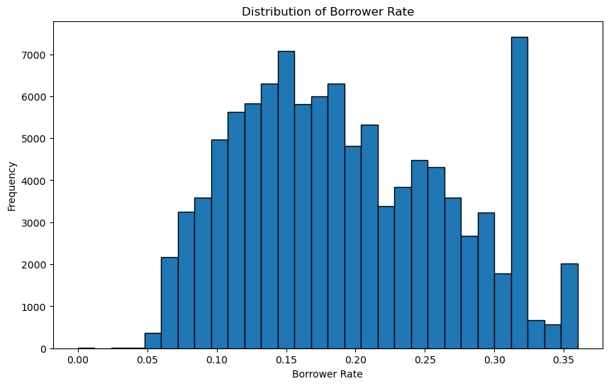

```python
plot_histograms(loan, 'BorrowerRate', 'Borrower Rate', 'Frequency')
```

**From the histogram wee see there is squet to the rigth**

Build a histogram for LenderYield column

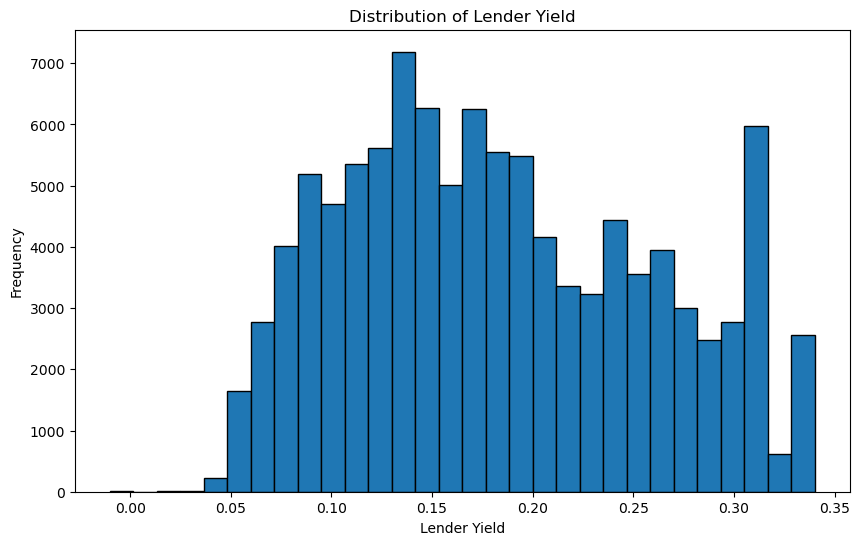

```python
plot_histograms(loan, 'LenderYield', 'Lender Yield', 'Frequency')
```

**From the histogram wee see there is squet to the rigth**

Build a histogram for ListingCategory (numeric) column

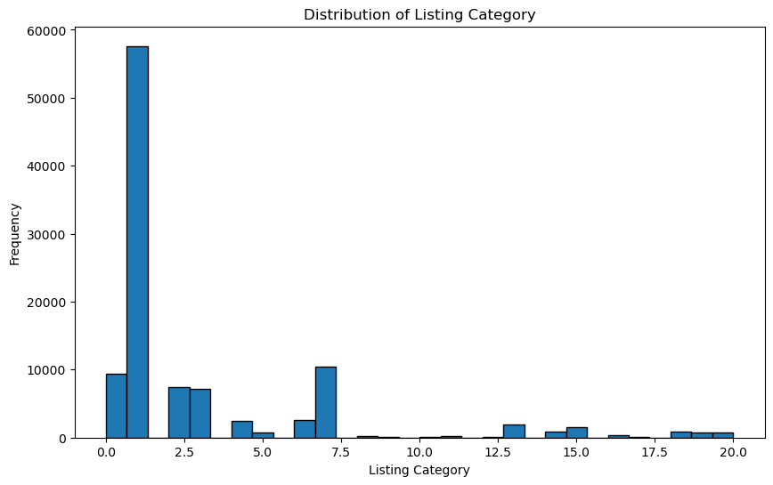

```python
plot_histograms(loan, 'ListingCategory (numeric)', 'Listing Category', 'Frequency')
```

**From the histogram wee most of data is between 0 and 3 and there is a lot of 7**

Build a histogram for EmploymentStatusDuration column

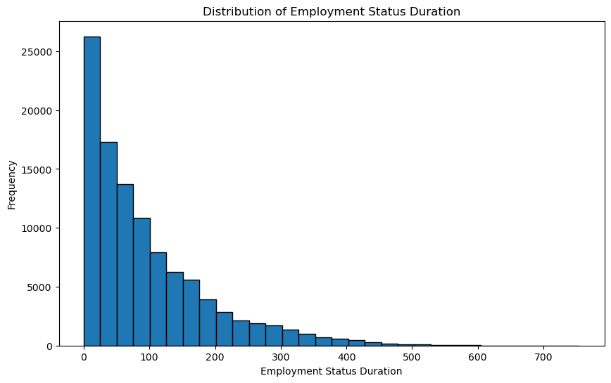

```python
plot_histograms(loan, 'EmploymentStatusDuration', 'Employment Status Duration', 'Frequency')
```

**From the histogram wee see there is strong squet to the rigth**

Build a histogram for LoanOriginalAmount column

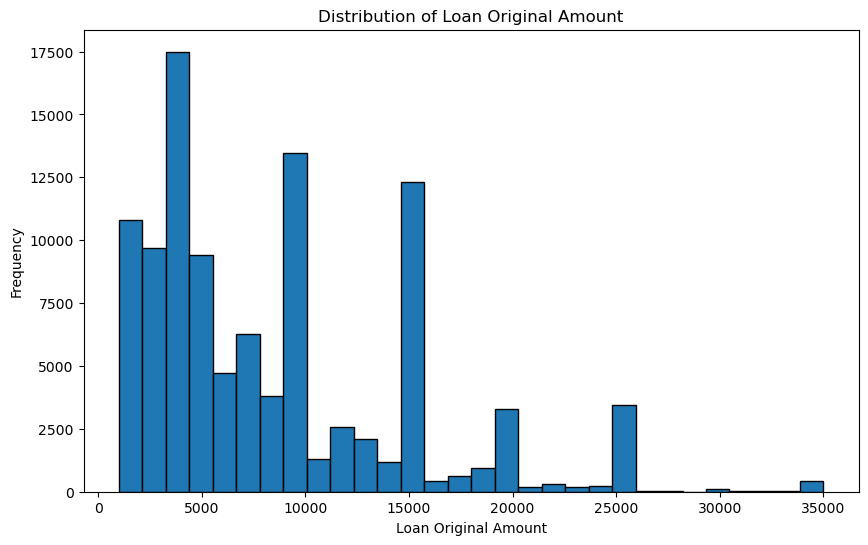

```python
plot_histograms(loan, 'LoanOriginalAmount', 'Loan Original Amount', 'Frequency')
```

**The data is rugfly skeed to the rigth and there is outliers**

Build a histogram for MonthlyLoanPayment column

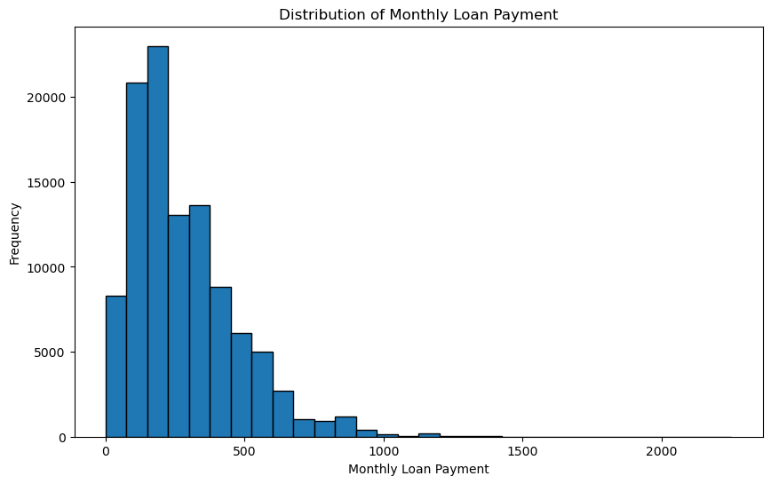

```python
plot_histograms(loan, 'MonthlyLoanPayment', 'Monthly Loan Payment', 'Frequency')
```

**Most of the data is between 0 and 500 nad it skweed to the rigth**

Create function for ordinal columns

```python
def plot_ordinal_sorted_bar_chart(data, column, x_label, y_label, sort_order):
    plt.figure(figsize=(14, 8))
    sns.countplot(data=data, x=column, order=sort_order, color='tab:blue')
    plt.title(f'Distribution of {x_label} (Ordinal Sorted)')
    plt.xlabel(x_label)
    plt.ylabel(y_label)
    plt.xticks(rotation=90)
    plt.show()

# For sorted
def plot_sorted_bar_chart(data, column, x_label, y_label):
    plt.figure(figsize=(14, 8))
    sorted_order = data[column].value_counts().index
    sns.countplot(data=data, x=column, order=sorted_order, color='tab:blue')
    plt.title(f'Distribution of {x_label}')
    plt.xlabel(x_label)
    plt.ylabel(y_label)
    plt.xticks(rotation=90)
    plt.show()

categorical_columns = [
    'LoanStatus', 'EmploymentStatus', 'IncomeRange', 'IsBorrowerHomeowner',
    'IncomeVerifiable', 'LoanOriginationQuarter'
]
```

Build a bar plot for LoanStatus column

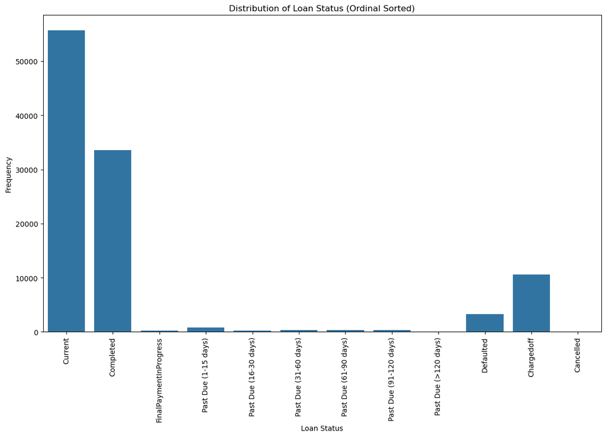

```python
ordinal_sort_order = [
    'Current', 'Completed', 'FinalPaymentInProgress', 'Past Due (1-15 days)',
    'Past Due (16-30 days)', 'Past Due (31-60 days)', 'Past Due (61-90 days)',
    'Past Due (91-120 days)', 'Past Due (>120 days)', 'Defaulted', 'Chargedoff', 'Cancelled'
]
plot_ordinal_sorted_bar_chart(loan, 'LoanStatus', 'Loan Status', 'Frequency', ordinal_sort_order)
```

**Bar plot for Loan Status showes most loan status is current and completed**

Build a bar plot for EmploymentStatus column

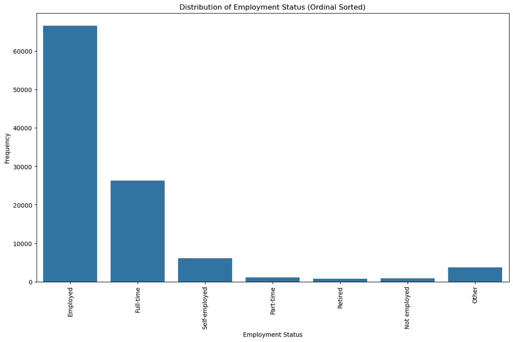

```python
employment_sort_order = [
    'Employed', 'Full-time', 'Self-employed', 'Part-time', 'Retired', 'Not employed', 'Other'
]
plot_ordinal_sorted_bar_chart(loan, 'EmploymentStatus', 'Employment Status', 'Frequency', employment_sort_order)
```

**The employe how take a loan is most of them employed and full time**

Build a bar plot for IncomeRange column

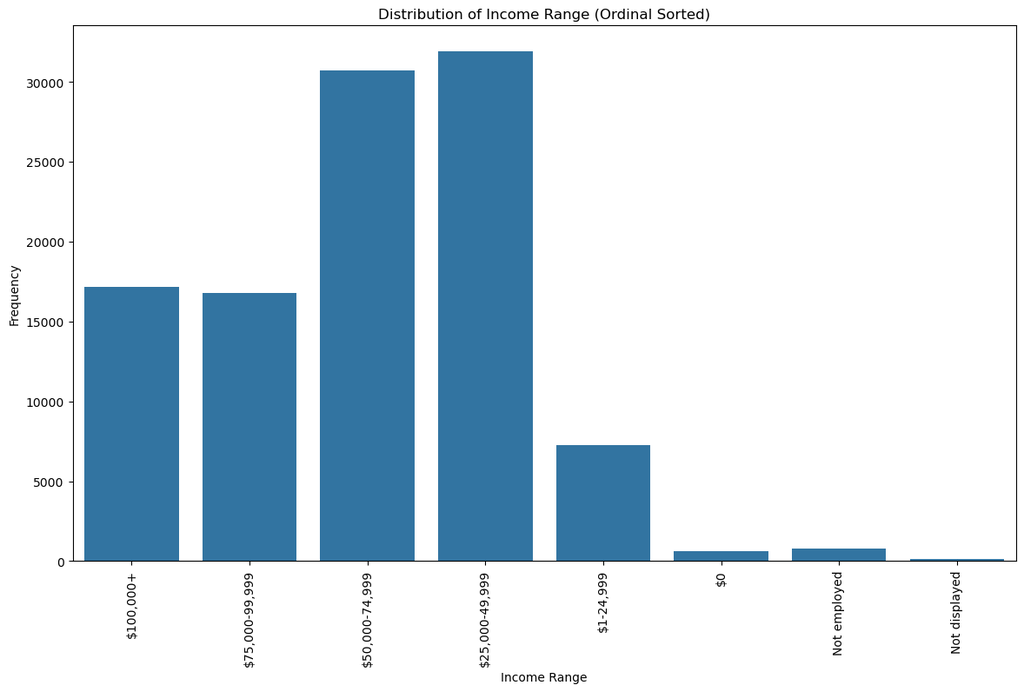

```python
income_sort_order = [
    '$100,000+', '$75,000-99,999', '$50,000-74,999','$25,000-49,999' , '$1-24,999'
    ,'$0' , 'Not employed', 'Not displayed'
]
plot_ordinal_sorted_bar_chart(loan, 'IncomeRange', 'Income Range', 'Frequency', income_sort_order)
```

**The income range of people how take a loan is most of them takes 25k to 50k and 50k to 75k**

Build a bar plot for IsBorrowerHomeowner column

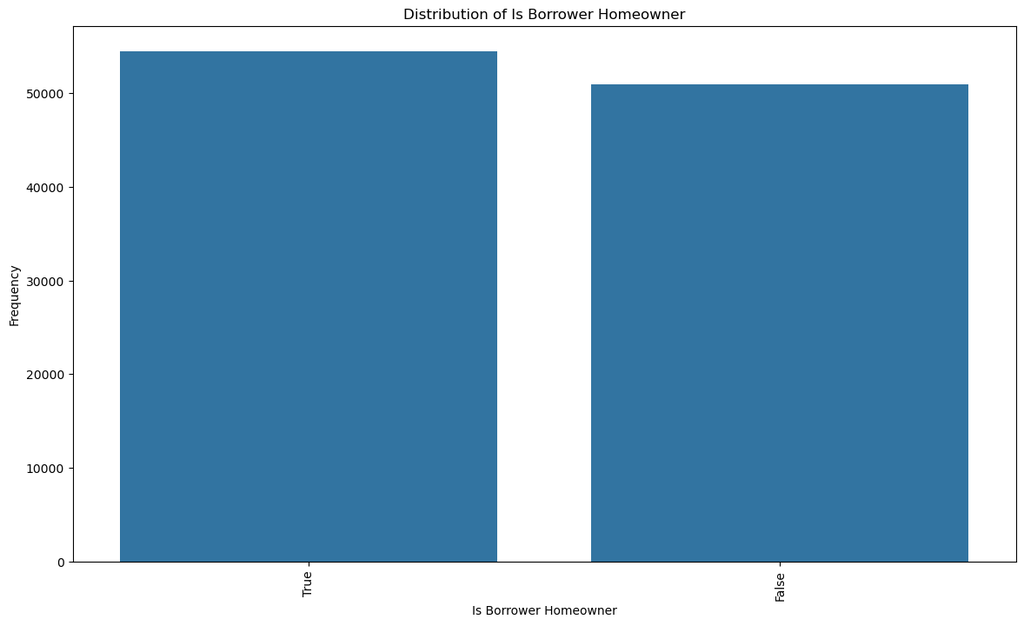

```python
plot_sorted_bar_chart(loan, 'IsBorrowerHomeowner', 'Is Borrower Homeowner', 'Frequency')
```

Build a bar plot for IncomeVerifiable column

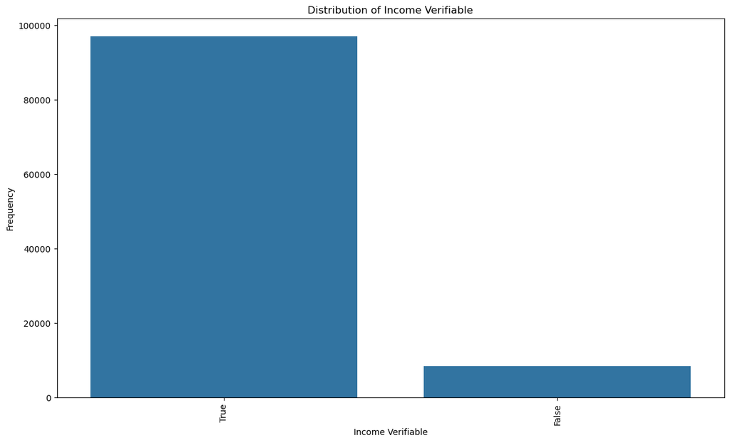

```python
plot_sorted_bar_chart(loan, 'IncomeVerifiable', 'Income Verifiable', 'Frequency')
```

**Most of the Income are varifiable**

Build a bar plot for LoanOriginationQuarter column

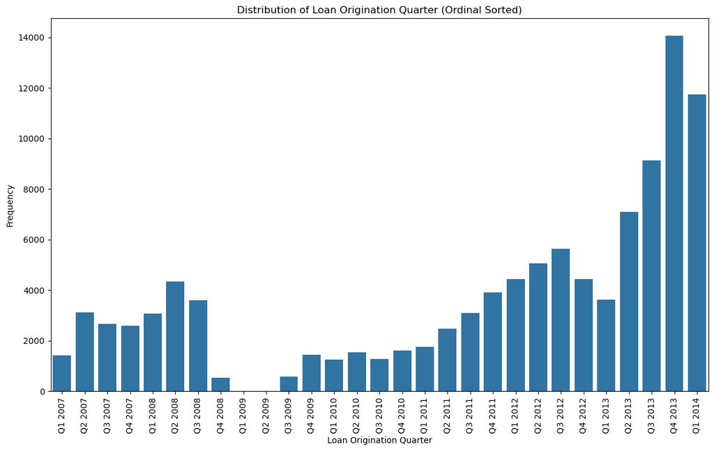

```python
quarter_sort_order = [
    'Q1 2007', 'Q2 2007', 'Q3 2007', 'Q4 2007', 'Q1 2008', 'Q2 2008', 'Q3 2008', 'Q4 2008',
    'Q1 2009', 'Q2 2009', 'Q3 2009', 'Q4 2009', 'Q1 2010', 'Q2 2010', 'Q3 2010', 'Q4 2010',
    'Q1 2011', 'Q2 2011', 'Q3 2011', 'Q4 2011', 'Q1 2012', 'Q2 2012', 'Q3 2012', 'Q4 2012',
    'Q1 2013', 'Q2 2013', 'Q3 2013', 'Q4 2013', 'Q1 2014'
]
plot_ordinal_sorted_bar_chart(loan, 'LoanOriginationQuarter', 'Loan Origination Quarter', 'Frequency', quarter_sort_order)
```

**The Loan Origination Quarter is increasing by the time**

### Bivariate exploration

Here is a heat map for the numaric fetures

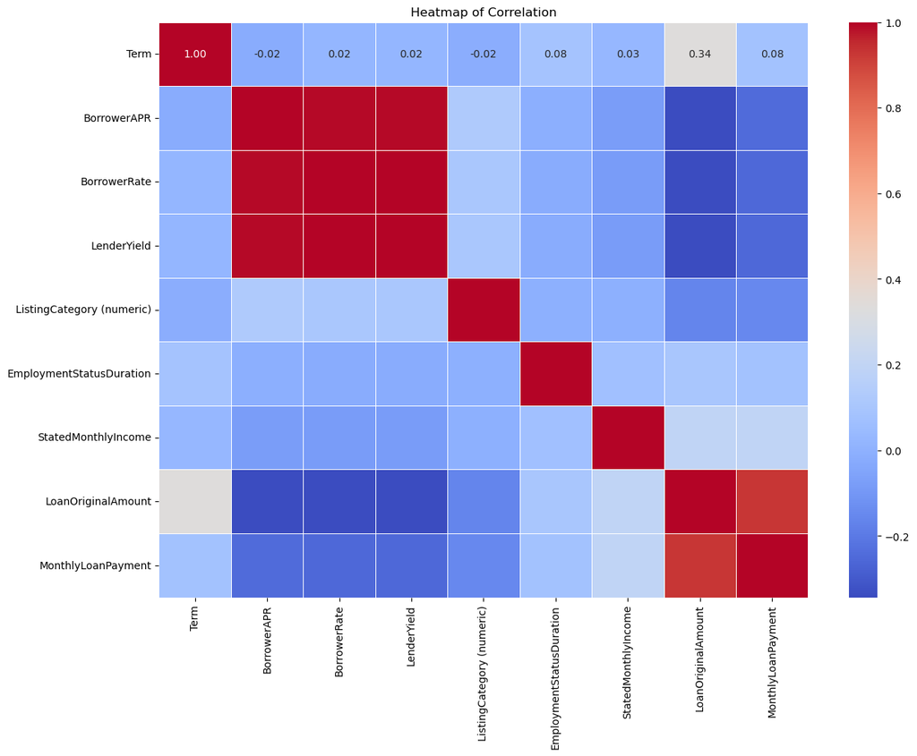

```python
    numerical_columns = loan.select_dtypes(include=['float64', 'int64']).columns
    numerical_data = loan[numerical_columns]

    # Plot the heatmap
    plt.figure(figsize=(14, 10))
    sns.heatmap(numerical_data.corr(), annot=True, fmt=".2f", cmap='coolwarm', linewidths=0.5)
    plt.title('Heatmap of Correlation')
    plt.show()
```

Box plots for the numaric data with employment status

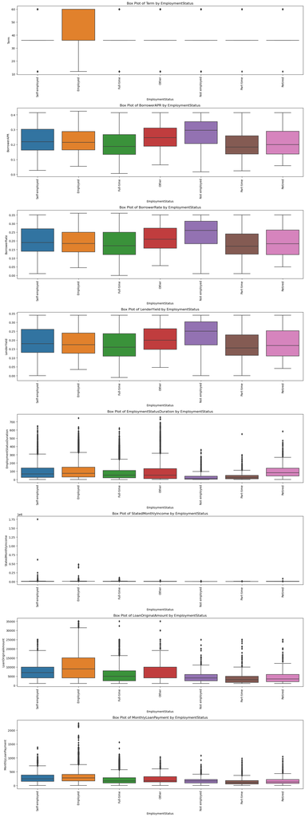

```python
selected_columns = [
    'Term', 'BorrowerAPR', 'BorrowerRate', 'LenderYield',
    'EmploymentStatusDuration', 'StatedMonthlyIncome',
    'LoanOriginalAmount', 'MonthlyLoanPayment'
]

# Define the categorical variable for the box plot
categorical_column = 'EmploymentStatus'

# Set up the matplotlib figure
fig, axes = plt.subplots(len(selected_columns), 1, figsize=(15, len(selected_columns)*5))

# Create box plots for each numerical column against the categorical column
for i, column in enumerate(selected_columns):
    sns.boxplot(ax=axes[i], x=categorical_column, y=column, data=loan)
    axes[i].set_title(f'Box Plot of {column} by {categorical_column}')
    axes[i].set_xlabel(categorical_column)
    axes[i].set_ylabel(column)
    axes[i].tick_params(axis='x', rotation=90)

# Adjust layout
plt.tight_layout()
plt.show()
```

**shows the desrtibution between the data between all numaric values and the Employment Status and the outlieres that have**

A scatter plots showes the relations between the data

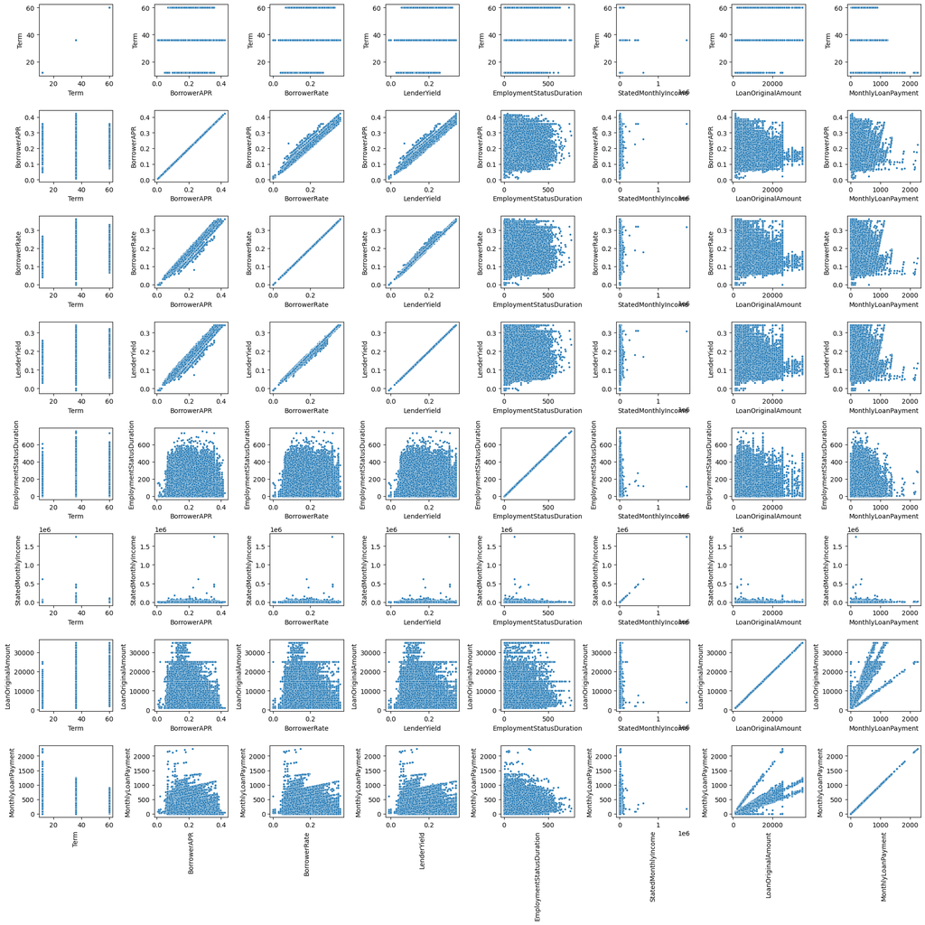

```python
selected_columns = [
    'Term', 'BorrowerAPR', 'BorrowerRate', 'LenderYield',
    'EmploymentStatusDuration', 'StatedMonthlyIncome',
    'LoanOriginalAmount', 'MonthlyLoanPayment'
]

# Set up the matplotlib figure
num_columns = len(selected_columns)
fig, axes = plt.subplots(num_columns, num_columns, figsize=(20, 20))

# Create scatter plots for each pair of numerical columns
for i in range(num_columns):
    for j in range(num_columns):
        sns.scatterplot(ax=axes[i, j], x=loan[selected_columns[j]], y=loan[selected_columns[i]], s=10)

        if i == num_columns - 1:
            axes[i, j].set_xlabel(selected_columns[j], rotation=90)
        if j == 0:
            axes[i, j].set_ylabel(selected_columns[i])

# Adjust layout
plt.tight_layout()
plt.show()
```

**We can see here the relation between all the columns**

### Multivariate exploration

Create a Facet Grid

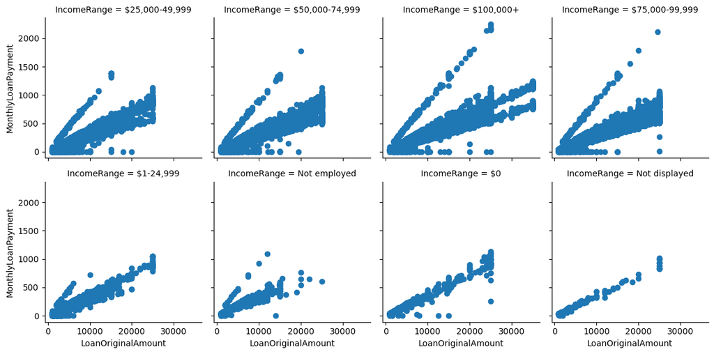

```python
plot = sns.FacetGrid(data=loan, col='IncomeRange', col_wrap=4)
plot.map(plt.scatter, 'LoanOriginalAmount', 'MonthlyLoanPayment');
```

**Create a Facet Grid for Income Range between LoanOriginalAmount and MonthlyLoanPayment featurs and i see there is a relation it the people take a much larger loan if it income range larger**

Creating a scatter plot FacetGrid for BorrowerRate, MonthlyLoanPayment

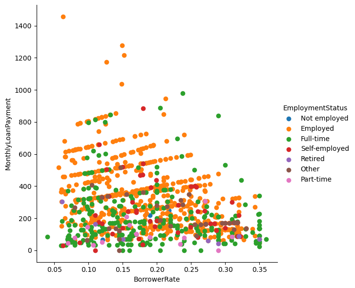

```python
loan_sample = loan.sample(frac=0.01, random_state=1)  # Adjust the fraction as needed

# Creating a scatter plot FacetGrid for BorrowerRate, MonthlyLoanPayment with EmploymentStatus as color encoding
plot = sns.FacetGrid(data=loan_sample, hue='EmploymentStatus', height=6)
plot.map(plt.scatter, 'BorrowerRate', 'MonthlyLoanPayment')
plot.add_legend()

plt.show()
```

**After we created a scatter plot FacetGrid for BorrowerRate, MonthlyLoanPayment with EmploymentStatus as color encoding we can see that is if the person employed it will or Full-time take a loan the monthly loan payment is much larger**

## Conclusions

### Exploratory Data Analysis Summary

#### The dataset containes many columns but after data wrangling we just have 17 column that we seen it as useful for our anaysis

then we exploring it and fined a lot of good informations and found the relations between fetures and how they affected eachother now i can answer any question about this dataset with drawing a visalizaion that make the stackholders understanding what im trying to say and in Explanatory data analysis i will answering thous questions and make a clear and informative visualization for it :

## *Q1_ What is the distribution of loan terms (in months) among the loans in the dataset?*

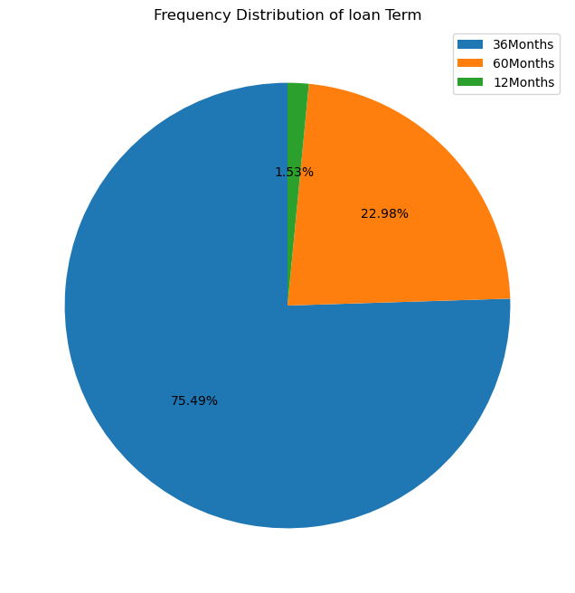

```python
plt.figure(figsize=[8,8])
labels = '36Months','60Months','12Months'
plt.pie(loan['Term'].value_counts(), autopct='%1.2f%%',startangle=90)
plt.title('Frequency Distribution of loan Term')
plt.legend(labels);
```

As we see most loan done in 36 month so we can target thous category with strong advertisments and offers to improve the income of this company and to push others to take loans from this category

## *Q2_ How is the frequency of different employment statuses distributed in the dataset, and what are the counts for each category?*

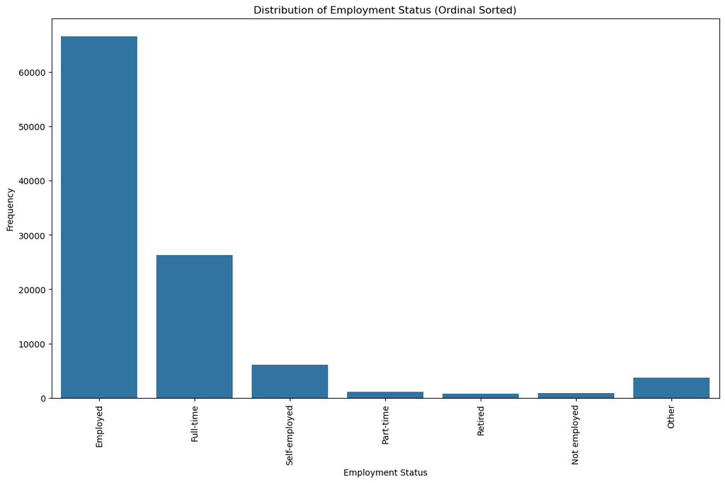

```python
employment_sort_order = [
    'Employed', 'Full-time', 'Self-employed', 'Part-time', 'Retired', 'Not employed', 'Other'
]
plot_ordinal_sorted_bar_chart(loan, 'EmploymentStatus', 'Employment Status', 'Frequency', employment_sort_order)
```

We can see most of people who toke a loan is employed or full-time so it can pay the Monthly Loan Payment

## *Q3_ What is the frequency distribution of borrowers income ranges in the dataset, and how do the counts compare across predefined income categories?*

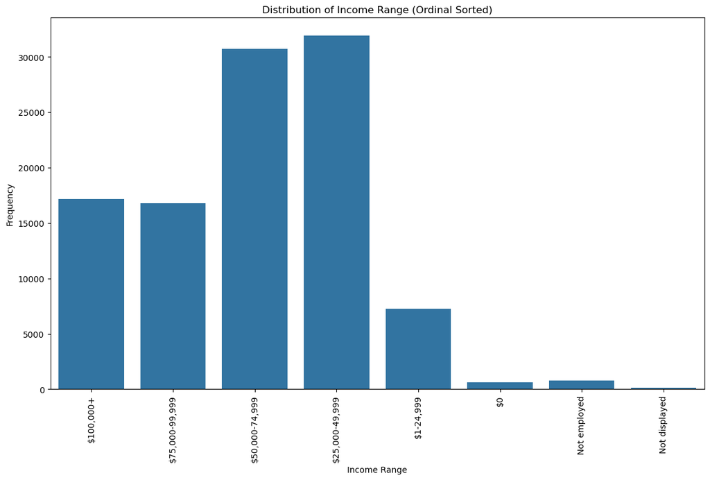

```python
income_sort_order = [
    '$100,000+', '$75,000-99,999', '$50,000-74,999','$25,000-49,999' , '$1-24,999'
    ,'$0' , 'Not employed', 'Not displayed'
]
plot_ordinal_sorted_bar_chart(loan, 'IncomeRange', 'Income Range', 'Frequency', income_sort_order)
```

We can see here most people who take loans in the people with income range between 25k - 50 k and the 50k - 70k

## *Q4_ How are loans distributed across different loan origination quarters in the dataset, and what are the counts for each quarter over time?*

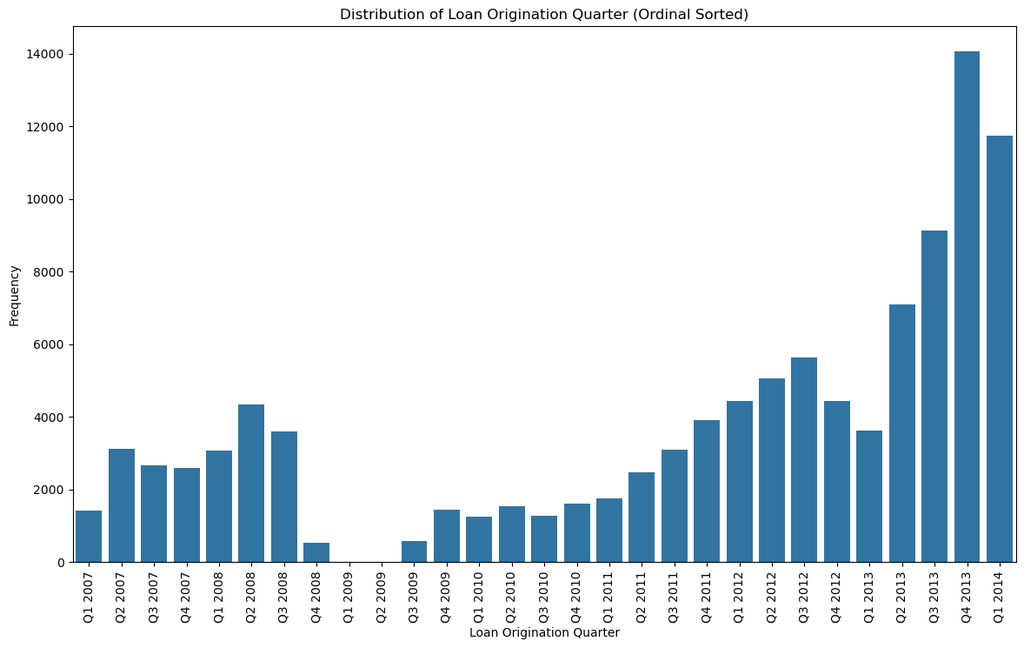

```python
quarter_sort_order = [
    'Q1 2007', 'Q2 2007', 'Q3 2007', 'Q4 2007', 'Q1 2008', 'Q2 2008', 'Q3 2008', 'Q4 2008',
    'Q1 2009', 'Q2 2009', 'Q3 2009', 'Q4 2009', 'Q1 2010', 'Q2 2010', 'Q3 2010', 'Q4 2010',
    'Q1 2011', 'Q2 2011', 'Q3 2011', 'Q4 2011', 'Q1 2012', 'Q2 2012', 'Q3 2012', 'Q4 2012',
    'Q1 2013', 'Q2 2013', 'Q3 2013', 'Q4 2013', 'Q1 2014'
]
plot_ordinal_sorted_bar_chart(loan, 'LoanOriginationQuarter', 'Loan Origination Quarter', 'Frequency', quarter_sort_order)
```

We conclude from these visual that there is an increase in the number of loans over time, and we can expect an increase also for the coming quarters, from which we can see an increase in the company’s profits and research behind why people need more loans.

## *Q5_ What is the strongest correlation with Monthly Loan Payment?*

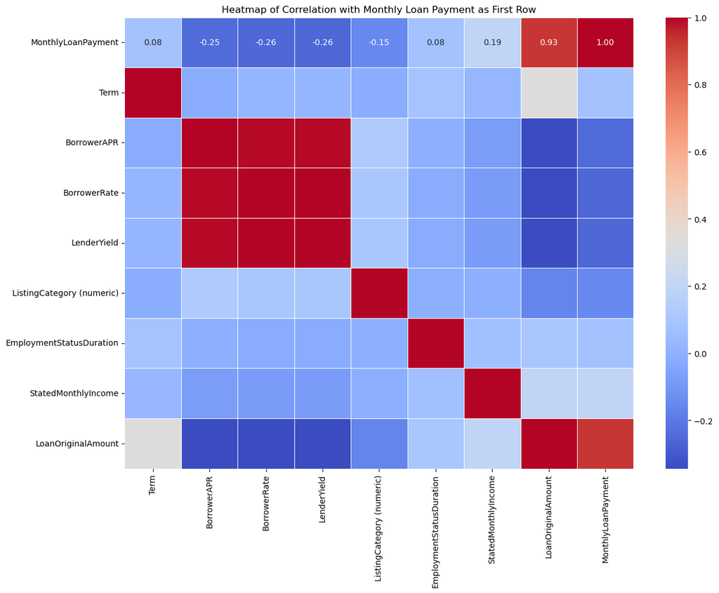

```python
# Select numerical columns
numerical_columns = loan.select_dtypes(include=['float64', 'int64']).columns

# Calculate the correlation matrix
corr_matrix = loan[numerical_columns].corr()

# Reorder the correlation matrix to have 'MonthlyLoanPayment' as the first row
corr_matrix = corr_matrix.loc[['MonthlyLoanPayment'] + [col for col in corr_matrix if col != 'MonthlyLoanPayment']]

# Plot the heatmap
plt.figure(figsize=(14, 10))
sns.heatmap(corr_matrix, annot=True, fmt=".2f", cmap='coolwarm', linewidths=0.5)
plt.title('Heatmap of Correlation with Monthly Loan Payment as First Row')
plt.show()
```

This visualization shows that the most strongest corrolation with Monthly Loan Payment is Loan Original Amount and this normal ,the higher the value of the loan , the greater the repayment you pay each month loan.

## *Q6_ How does the relationship between the original loan amount and monthly loan payment vary across different income ranges?*

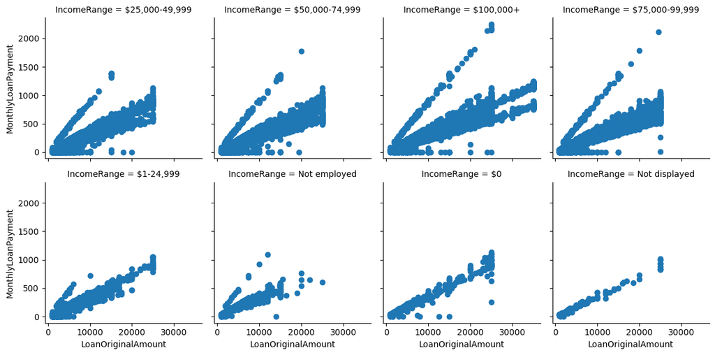

```python
plot = sns.FacetGrid(data=loan, col='IncomeRange', col_wrap=4)
plot.map(plt.scatter, 'LoanOriginalAmount', 'MonthlyLoanPayment');
```

We can see here that the increasing of the income reange will icreasing also the loan origin amount, we also know if the person in rech and take a loan the loan most be a huge amount loan

## *Q7_ How does the Borrower APR vary across different loan terms and employment statuses?*

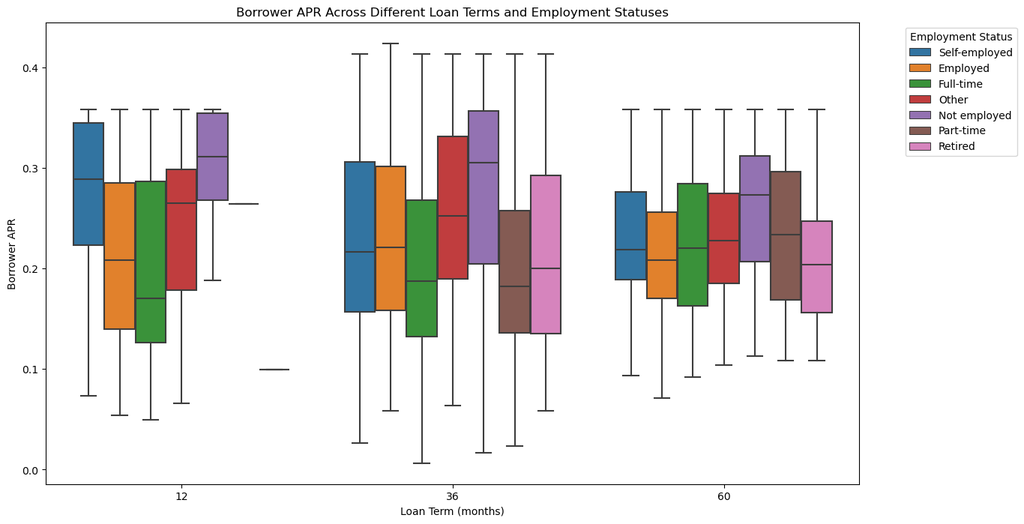

```python
plt.figure(figsize=(14, 8))
sns.boxplot(data=loan, x='Term', y='BorrowerAPR', hue='EmploymentStatus')
plt.title('Borrower APR Across Different Loan Terms and Employment Statuses')
plt.xlabel('Loan Term (months)')
plt.ylabel('Borrower APR')
plt.legend(title='Employment Status', bbox_to_anchor=(1.05, 1), loc='upper left')
plt.show()
```

## *Q8_ How does the Monthly Loan Payment vary for different loan statuses and whether the borrower is a homeowner or not?*

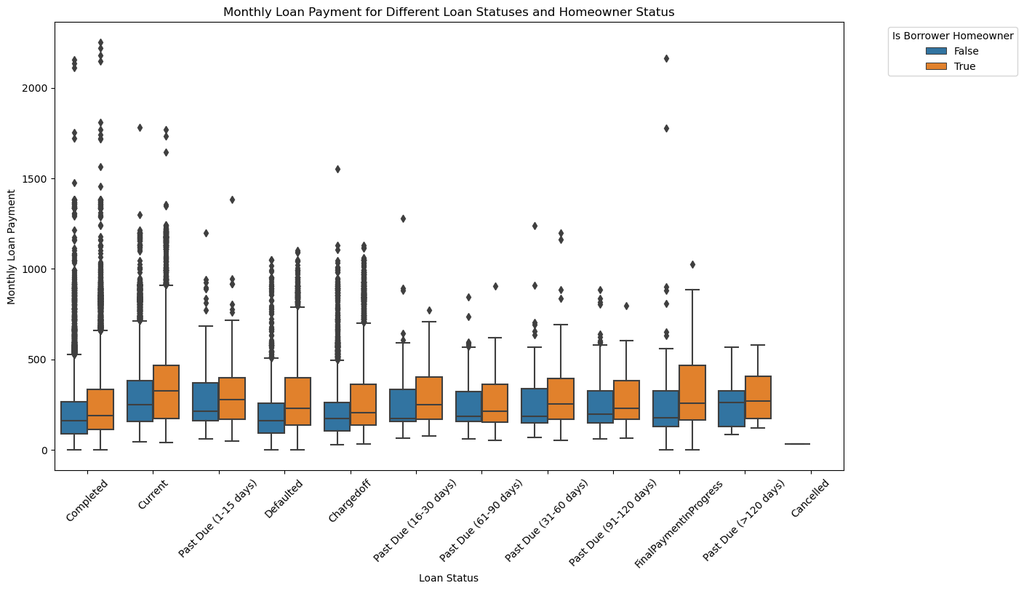

```python
plt.figure(figsize=(14, 8))
sns.boxplot(data=loan, x='LoanStatus', y='MonthlyLoanPayment', hue='IsBorrowerHomeowner')
plt.title('Monthly Loan Payment for Different Loan Statuses and Homeowner Status')
plt.xlabel('Loan Status')
plt.ylabel('Monthly Loan Payment')
plt.legend(title='Is Borrower Homeowner', bbox_to_anchor=(1.05, 1), loc='upper left')
plt.xticks(rotation=45)
plt.show()
```